# Exploration of time usage and distance travelled of FordGoBikes

## Investigation Overview

In this investigation, I was most interested in figuring out how long is a bike ride on an average, in the provided dataset. Also, the distance traveled by the bike.

## Dataset Overview

The data consisted of the 192082 times the bikes have been issued by the Ford Go Bikes company in January, 2019. There are 14 columns out of which the numerical variable is the duration column containing the number of seconds the bike was issued for.

```python
# import all packages and set plots to be embedded inline
import numpy as np
import pandas as pd
import matplotlib.pyplot as plt
import seaborn as sb

%matplotlib inline

# suppress warnings from final output
import warnings
warnings.simplefilter("ignore")
```

```python
# load in the dataset into a pandas dataframe
df = pd.read_csv('fordgobike-tripdata.csv')
df.head()
```

|  | duration_sec | start_time | end_time | start_station_id | start_station_name | start_station_latitude | start_station_longitude | end_station_id | end_station_name | end_station_latitude | end_station_longitude | bike_id | user_type | bike_share_for_all_trip |
| --- | --- | --- | --- | --- | --- | --- | --- | --- | --- | --- | --- | --- | --- | --- |
| 0 | 80825 | 2019-01-31 17:57:44.6130 | 2019-02-01 16:24:49.8640 | 229.0 | Foothill Blvd at 42nd Ave | 37.775745 | -122.213037 | 196.0 | Grand Ave at Perkins St | 37.808894 | -122.256460 | 4861 | Subscriber | No |
| 1 | 65900 | 2019-01-31 20:58:33.8860 | 2019-02-01 15:16:54.1730 | 4.0 | Cyril Magnin St at Ellis St | 37.785881 | -122.408915 | 134.0 | Valencia St at 24th St | 37.752428 | -122.420628 | 5506 | Subscriber | No |
| 2 | 62633 | 2019-01-31 18:06:52.9240 | 2019-02-01 11:30:46.5300 | 245.0 | Downtown Berkeley BART | 37.870139 | -122.268422 | 157.0 | 65th St at Hollis St | 37.846784 | -122.291376 | 2717 | Customer | No |
| 3 | 44680 | 2019-01-31 19:46:09.7190 | 2019-02-01 08:10:50.3180 | 85.0 | Church St at Duboce Ave | 37.770083 | -122.429156 | 53.0 | Grove St at Divisadero | 37.775946 | -122.437777 | 4557 | Customer | No |
| 4 | 60709 | 2019-01-31 14:19:01.5410 | 2019-02-01 07:10:51.0650 | 16.0 | Steuart St at Market St | 37.794130 | -122.394430 | 28.0 | The Embarcadero at Bryant St | 37.787168 | -122.388098 | 2100 | Customer | No |

> Note that the above cells have been set as "Skip"-type slides. That means that when the notebook is rendered as http slides, those cells won't show up.

```python
# convert user_type into ordered categorical types
ordinal_var_dict = {'user_type': ['Subscriber', 'Customer']}

for var in ordinal_var_dict:
    ordered_var = pd.api.types.CategoricalDtype(ordered = True, categories = ordinal_var_dict[var])
    df[var] = df[var].astype(ordered_var)
```

```python
#converting unwanted ints into strings
df.start_station_id = df.start_station_id.astype(str)
df.end_station_id = df.end_station_id.astype(str)
df.bike_id = df.bike_id.astype(str)
```

```python
# Converting logitudes and Latitudes into distances using haversine formula
def haversine_np(lon1, lat1, lon2, lat2):
    """
    Calculate the great circle distance between two points
    on the earth (specified in decimal degrees)
    All args must be of equal length.
    """
    lon1, lat1, lon2, lat2 = map(np.radians, [lon1, lat1, lon2, lat2])
    dlon = lon2 - lon1
    dlat = lat2 - lat1
    a = np.sin(dlat/2.0)**2 + np.cos(lat1) * np.cos(lat2) * np.sin(dlon/2.0)**2
    c = 2 * np.arcsin(np.sqrt(a))
    km = 6367 * c
    return km
```

```python
# Applying haversine
df['distance'] = haversine_np(df['start_station_longitude'],df['start_station_latitude'],df['end_station_longitude'],df['end_station_latitude'])
```

## Duration spent on bikes

> The duration of the bike being ridden is unimodal, but still skewed to the right even after performing log values. This means that the bikes are ridden for smaller durations more than longer durations.

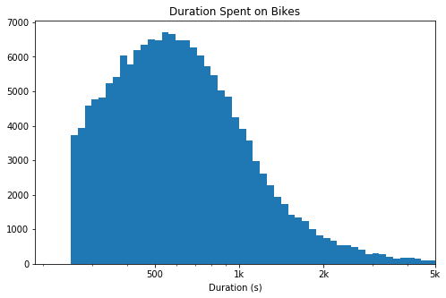

```python
# there's a long tail in the distribution, so let's put it on a log scale instead
log_binsize = 0.025
bins = 10 ** np.arange(2.4, np.log10(df['duration_sec'].max())+log_binsize, log_binsize)

plt.figure(figsize=[8, 5])
plt.hist(data = df, x = 'duration_sec', bins = bins)
plt.xscale('log')
plt.xticks([500, 1e3, 2e3, 5e3, 1e4, 2e4], [500, '1k', '2k', '5k', '10k', '20k'])
plt.xlabel('Duration (s)')
plt.xlim(0, 5e3)
plt.title('Duration Spent on Bikes')
plt.show();
```

## Distribution of the user types

> Clearly there are more subscribers to the company service than ordinary customers.

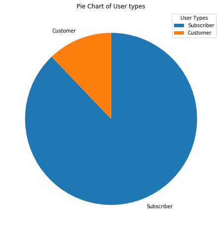

```python
#Having a look at subscribers vs Customers
sorted_counts = df['user_type'].value_counts()
plt.figure(figsize=(8,8))

plt.pie(sorted_counts, labels = sorted_counts.index,  startangle=90, counterclock = False);
plt.legend(['Subscriber', 'Customer'], title='User Types')
plt.title('Pie Chart of User types');
```

## Distance travelled on bikes

> This graph shows us that the distance is quite bimodal with some people traveling for less than quarter of a kilometer while the majority of the users are riding for 1 - 1.5 kilometers. Then it decreases as the distance increases.

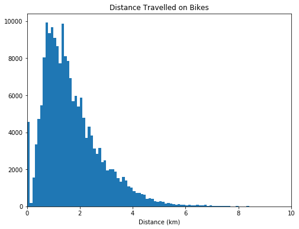

```python
bin_edges = np.arange(0, df['distance'].max()+0.1, 0.1)

plt.figure(figsize = (8, 6))
plt.hist(data=df, x='distance', bins = bin_edges)
plt.xlabel('Distance (km)');
plt.xlim(0, 10)
plt.title('Distance Travelled on Bikes');
```

```python
numeric_vars = ['duration_sec', 'distance']
categoric_vars = ['user_type']
```

## Duration vs Distance correlation

> There is a correlation of 0.139 between distance and duration. That means there is a weak relationship between the two numeric variables present in this data.

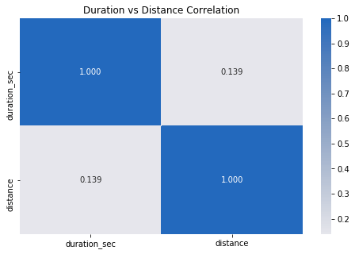

```python
# correlation plot
plt.figure(figsize = [8, 5])
sb.heatmap(df[numeric_vars].corr(), annot = True, fmt = '.3f',cmap = 'vlag_r', center = 0)
plt.title('Duration vs Distance Correlation')
plt.show();
```

```python
def freq_poly(x, bins=10, **kwargs):
    if type(bins)==int:
        bins=np.linspace(x.min(), x.max(), bins+1)
    bin_centers = (bin_edges[1:] + bin_edges[:1])/2

    data_bins=pd.cut(x, bins, right=False, include_lowest = True)
    counts = x.groupby(data_bins).count()

    plt.errorbar(x=bin_centers, y=counts, **kwargs)
```

## Distance and Duration vs User types

The correlation between both the numerical variables namely duration_sec and distance is 0.139, implying that there is a very weak relation between the two variables. However, when I plotted a frequency polygon line plot, we can see that most bikes take less duration of time.

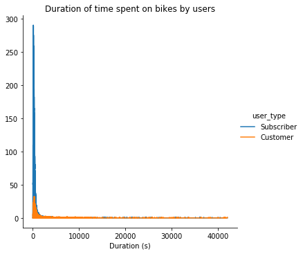

```python
bin_edges = np.arange(-3, df['duration_sec'].max()+1/3, 1/3)
g = sb.FacetGrid(data=df, hue = 'user_type', size=5)
g.map(freq_poly, "duration_sec", bins = bin_edges)
g.add_legend()
plt.xlabel('Duration (s)')
plt.title('Duration of time spent on bikes by users');
```

For the distance variable we can see that mostly users travel for 1.5 km, however there are users who go for more too.

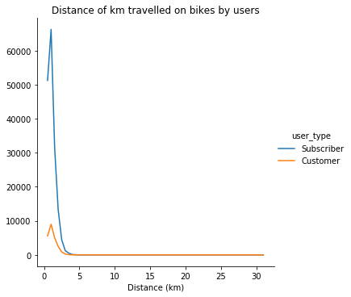

```python
bin_edges = np.arange(0, df['distance'].max()+1, 1)
g = sb.FacetGrid(data=df, hue = 'user_type', size=5)
g.map(freq_poly, "distance", bins = bin_edges)
g.add_legend()
plt.xlabel('Distance (km)')
plt.title('Distance of km travelled on bikes by users');
```

> Expected results were found. We could see that the subscribers are the users between both the type of users who use the bikes more. Even though, as we can interpret, that there are many outliers in the subscriber duration graph, in the customer duration graph, there are more users that use the bike for more time than the subscribers. But with immense number of outliers we can conclude that the subscribers use the bikes more.

> The dustance is more or less the same between the two groups, most of the users travel approximately 1.5 kilometers.

> Once you're ready to finish your presentation, check your output by using nbconvert to export the notebook and set up a server for the slides. From the terminal or command line, use the following expression:

> > `jupyter nbconvert <file_name>.ipynb --to slides --post serve --template output_toggle`

> This should open a tab in your web browser where you can scroll through your presentation. Sub-slides can be accessed by pressing 'down' when viewing its parent slide. Make sure you remove all of the quote-formatted guide notes like this one before you finish your presentation!